# R Notebook

1.- Si el peso del ganado vacuno de una raza se distribuye según una Normal con media 600 kilo y desviación estándar de 35 simule los pesos de 400 de estos ganados, simule y grafique un histograma con los datos.

```r
mu = 600
sigma = 35
n = 400

# Primera forma para simular la distribucion normal
dist_normal_1 <- function(n1, mu1, sigma1) {
  x = rep(0,n1)
  for(i in 1:n1) {
    u1 = runif(12, min=0,max=1)
    x[i] = sum(u1)-6
  }
  y = mu1 + sigma1*x
  return(y)
}

dnormal_1 = dist_normal_2(n, mu, sigma)
#dnormal_1
#hist(dnormal_1 , xlab="Peso de ganado (Kg)", ylab ="Frecuencia",
#     main="Distribución Normal Simulada")
```

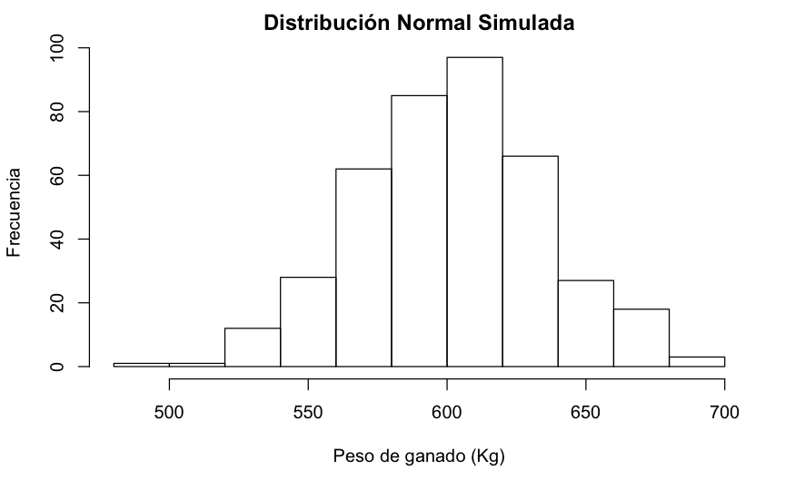

```r
# Segunda forma para simular la distribucion normal
dist_normal_2 <- function(n1, mu1, sigma1) {
  x = rep(0,n1)
  y = rep(0,n1)
  for(i in 1:n1){
    u1 = runif(1, min=0,max=1)
    u2 = runif(1, min=0,max=1)
    r = sqrt(-2*log(u1))
    theta = 2*pi*u2
    x[i] = r*cos(theta)
    y[i] = r*sin(theta)
    X = mu1 + sigma1*x
    Y = mu1 + sigma1*y
  }

  return(data.frame(X,Y))

}

dnormal_2 = dist_normal_2(n, mu, sigma)
hist(dnormal_2$X , xlab="Peso de ganado (Kg)", ylab ="Frecuencia",
     main="Distribución Normal Simulada")
```

2.- Al realizar un envío de obsequios por el día de la madre una tienda estimo que en el 6% de los casos los obsequios sufren accidentes, simule lo que pasa con 50 envíos.

Es una distribucion binomial

```r
# Donde n es la cantidad de datos a simular
# y theta es la probabilidad de exito
bernoulli <- function(n,theta) {
  uniformes=runif(n, min=0, max=1) # Mantenemos una linea constante
#  print(uniformes)
  resultados=rep(0,n)
  for (i in 1:n)
    if (uniformes[i]>=1-theta)
      resultados[i]=1
    else
      resultados[i]=0
  return(resultados)
}

# Salida:  1 -> sufrio accidente , 0 -> no sufrio accidente
bernoulli(1,0.06)
```

```
[1] 0
```

```r
# Funcion para generar numeros pseudoaleatorios
# de una distribucion Binomial con parametros
# r (nro. de repeticiones) y theta (segunda forma)
binomial <-function(n,r,theta) {
  x <- rep(0,n)

  for (i in 1:r)
    x[i]<-sum(bernoulli(n,theta))

  #print(x)
  prob = table(x)/r
  return(prob)
}

n = 1   # tamanho de la muestra
r = 50  # nro. de envios
p = 0.06 # probabilidad que los regalos no llegen a su destino

# Salida
#  x[0] : Numero de envios que llegan a su destino
#  x[1] : Numero de envios que NO llegan a su destino

set.seed(100)
r*binomial(n, r, p)
```

```
x
 0  1
48  2
```

Se observa que hay 48 pedidos que llegaron a su destino y 2 pedidos que no llegaron a su destino

3.- Detalle un ejemplo de aplicación de la simulación con la distribución geométrica y geométrica negativa.

## Simulación con distribucion geométrica

```r
#Funcion para generar numeros pseudoaleatorios de una distribucion geometrica con parametro theta
geometrica <- function(n,theta) {
  x=rep(0,n)
  for (i in 1:n) {
    U=runif(1)
    x[i]=floor(log(U)/log(1-theta))
  }
  print(x)
}

geometrica(12,0.4)
```

```
 [1] 1 0 3 3 3 1 1 0 1 0 5 0
```

4.- Presente un contexto para simular 100 datos con las funciones rlogis y rweibull (defina los parámetros según el contexto que elija)

## Distribución Logistica

Ejemplo : Se tiene ganado vacuno con un parametro de posición de 10 y un parametor de scale =2, generar 100 numero pseudo aleatorios con este principio

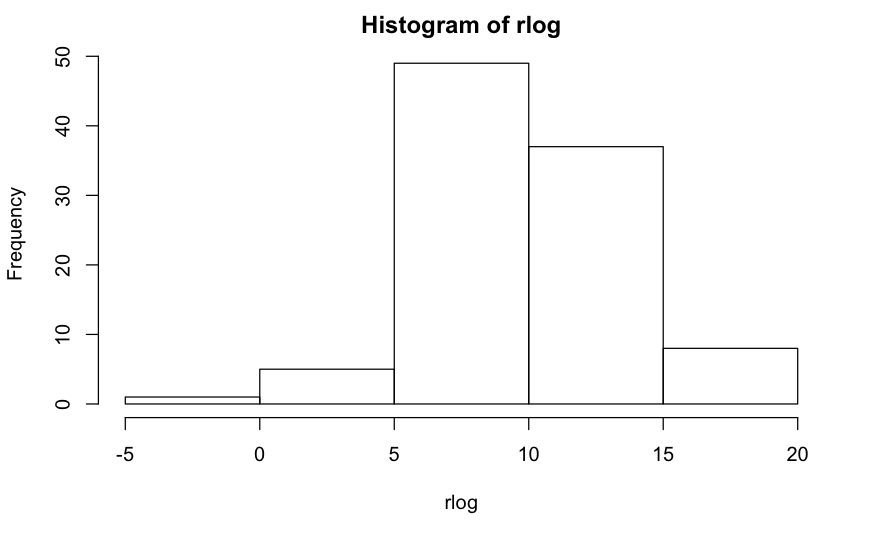

```r
n = 100
rlog = rlogis(n,10,2)
hist(rlog)
```

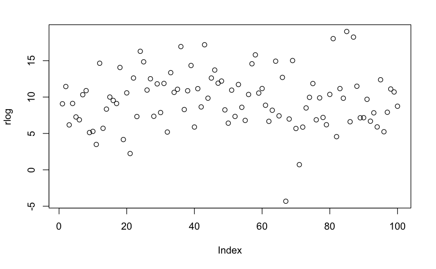

```r
plot(rlog)
```

## Distribución Weibull

Ejemplo : El tiempo de via X en horas de un artefacto en el taller de mecanica tiene una distribución de Weibull con alpha igual a 0,01 y con beta igual a 2 . Se desea simular 100 observaciones

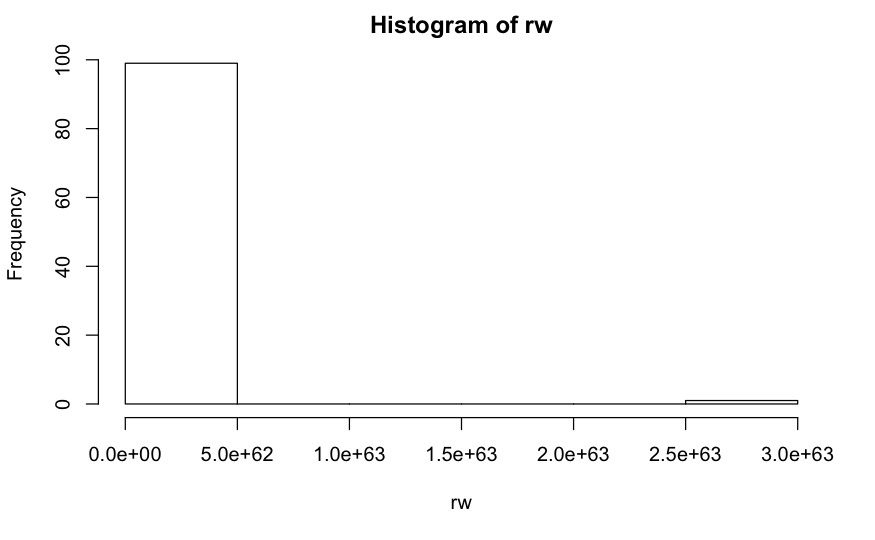

```r
n = 100
rw = rweibull(n, 0.01, 2)
hist(rw)
```

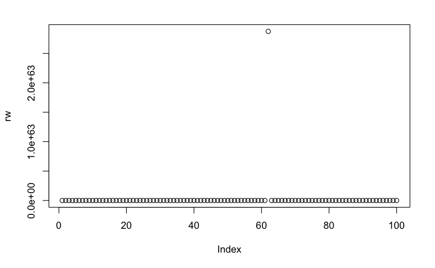

```r
plot(rw)
```

5.- Haga un programa que estime el coeficiente:
$$Ap_2 = \frac{3(3\bar{x}-2Me)}{4s}$$
Pruebe la función para los siguientes datos : 12.150 12.000 10.875 11.400 12.525 12.000 10.050 10.650 11.700 11.550 10.800 9.600 9.450 11.850 10.950 11.400 12.150 12.600 12.525 11.850 10.800 12.000 13.80 13.125 12.075 12.00 13.725 12.600 12.300 11.700 12.450 12.300 11.700 11.700 12.750 13.50 13.050 12.30 2.90

```r
# Calculo de estimados de ap2
ap2 <- function(datos) {

  media = mean(datos)
  mediana = median(datos)
  desviacion = sd(datos)
  estimador = 3*(3*media - 2*mediana)/(4*desviacion)
  return(estimador)

}

# Estimador bootstrap para RB
calc_bootstrap <- function(datos,B) {

  n = length(datos)
  estimac=rep(0,B)

  for (i in 1:B){
    muestra = sample(datos,n,T)
    estimac[i] = ap2(muestra)
  }

  estboot=mean(estimac)
  eeboot=sd(estimac)

  return(list(estimador=estboot,eestandar=eeboot, vector=estimac))

}

# Repeticiones de muestras boostrap
nro_muestras_bootstrap <- function(datos,B,r){

  ee=rep(0,r)

  for (i in 1:r)
    ee[i] = calc_bootstrap(datos,B)$eestandar

  cv=sd(ee)/abs(mean(ee))  # Coeficiente de variabilidad

  return(cv)
}
```

```r
set.seed(666)

datos = c(12.150, 12.000, 10.875, 11.400, 12.525, 12.000, 10.050, 10.650, 11.700, 11.550, 10.800,  9.600,  9.450, 11.850, 10.950, 11.400, 12.150, 12.600, 12.525, 11.850, 10.800, 12.000, 13.80, 13.125, 12.075, 12.00, 13.725, 12.600, 12.300, 11.700, 12.450, 12.300, 11.700, 11.700, 12.750, 13.50, 13.050, 12.30,  2.90)

#B = 10                    # Numero de muestras bootstrap
B = seq(0,100,2)
nro_rep = 100

cvs = rep(0,length(B))

for ( i in 1:length(B))
  cvs[i] = nro_muestras_bootstrap(datos,B[i],r)

cvs
```

```
 [1]         NA 0.87153805 0.44531353 0.28632302 0.22243461 0.22300046 0.18874666
 [8] 0.14936730 0.17850441 0.14066590 0.12356199 0.12654841 0.12132640 0.10642377
[15] 0.12115067 0.11830851 0.11391600 0.09443208 0.09955022 0.09740602 0.09946427
[22] 0.09791518 0.09007165 0.08576987 0.07980691 0.07550385 0.08836130 0.08303886
[29] 0.07213219 0.08537833 0.07662731 0.07213365 0.07581854 0.07206246 0.06998647
[36] 0.08057949 0.07884320 0.07056398 0.06564059 0.06770150 0.07383842 0.06145920
[43] 0.06974714 0.06186489 0.07162989 0.06035984 0.06464846 0.05983855 0.05716819
[50] 0.06380540 0.06185345
```

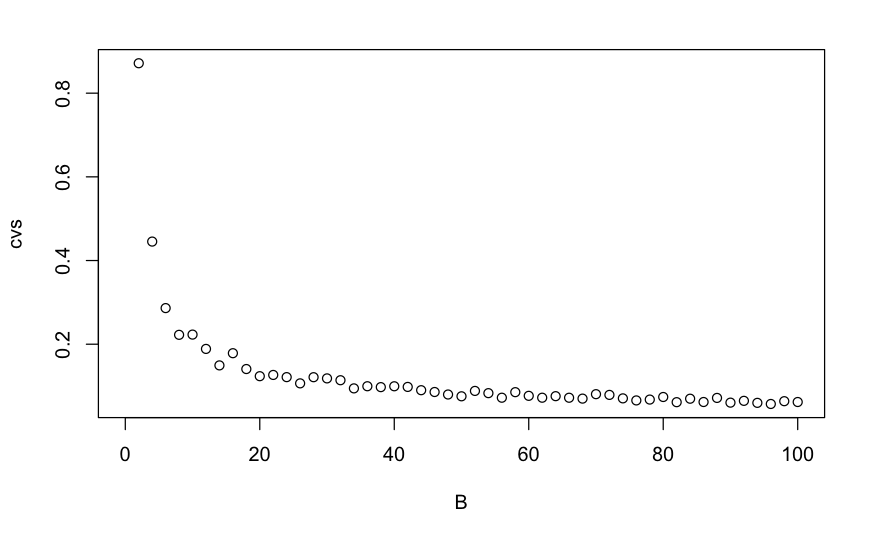

```r
plot(B,cvs)
```

2. ¿Calcule el Intervalo de confianza para el estadístico Ap2, con los métodos: Estandar, percentiles, estudentizado y doblemente estudentizado.

# Metodo estandar

```r
calc_ic_met_estandar <-function(datos, B,alpha ) {
  bstrap = calc_bootstrap(datos,B)

  media = bstrap$estimador
  desvStd = bstrap$eestandar

  lis = media - qnorm(1-alpha/2)*desvStd
  lss = media + qnorm(1-alpha/2)*desvStd
  rango = lss - lis

  return(data.frame("metodo"="normal", lis, lss, rango))
}

#set.seed(666)
#B = 20              # definido en la parte a) de la pregunta.
#alpha = 0.05
#calc_ic_met_estandar(datos,B, alpha)
```

# Metodo percentiles

```r
calc_ic_met_percentiles <-function(datos,B,alpha ) {

  bstrap = calc_bootstrap(datos,B)

  ap2vector =  bstrap$vector

  lis = quantile(ap2vector,alpha/2)
  lss = quantile(ap2vector,1-alpha/2)

  rango = lss - lis

  return(data.frame("metodo"="percentiles", lis, lss, rango))
}


#set.seed(666)
#
#B = 20              # definido en la parte a) de la pregunta.
#alpha = 0.05
#calc_ic_met_percentiles(datos,B,alpha)
```

# Metodo estudentizado

```r
calc_ic_met_estudentizado <-function(datos, B, alpha ) {

  bstrap = calc_bootstrap(datos,B)

  ap2Std    = bstrap$eestandar
  ap2vector = bstrap$vector
  ap2       = ap2(ap2vector)

  testud=rep(0,b)  # Inicializa el estudentizado

  testud = (ap2vector-ap2)/ap2Std

  lis = ap2 - quantile(testud,alpha/2)*ap2Std
  lss = ap2 + quantile(testud,1-alpha/2)*ap2Std

  rango = lss - lis

  return(data.frame("metodo"="estudentizado", lis, lss, rango))
}

#set.seed(666)
#alpha = 0.05        #
#B = 20              # definido en la parte a) de la pregunta.
# calc_ic_met_estudentizado(datos, B,alpha)
```

# Metodo doblemente estudentizado

```r
# Calcular IC usando el metodo de doble estudentizado
calc_ic_met_doble_estudentizado <- function(datos,B1,B2,alpha) {

  n = length(datos)
  estimacB1 = rep(0,B1)
  errorB1   = rep(0,B1)

  for (i in 1:B1){
    muestraB1 = sample(datos,n,T)
    estimacB1[i] = ap2(muestraB1)

    estimacB2 = rep(0,B2)
    for (k in 1:B2) {
      muestraB2 = sample(muestraB1,n,T)
      estimacB2[k] = ap2(muestraB2)
    }

    errorB1[i] = sd(estimacB2)
  }

  testud = rep(0,B1)   # t estudentizado , se hace para cada unos de la p muestras boostrap
  estimacBASE = ap2(datos)

  testud = (estimacB1-estimacBASE)/errorB1

  ap2Std = sd(estimacB1)

  lis = estimacBASE + quantile(testud,alpha/2)*ap2Std
  lss = estimacBASE + quantile(testud,1-alpha/2)*ap2Std

  rango = lss - lis

  return(data.frame("metodo"="doble_estudentizado", lis, lss, rango))
}

#set.seed(666)
#
#alpha = 0.05
#B1 = 20             # definido en la parte a) de la pregunta.
#B2 = 30             # definido en la parte a) de la pregunta.
#
#calc_ic_met_doble_estudentizado(datos,B1,B2,alpha)
```

```r
set.seed(1000)

alpha = 0.05
B = 20              # definido en la parte a) de la pregunta.
B1 = 20             # definido en la parte a) de la pregunta.
B2 = 30             #

df = rbind(calc_ic_met_estandar(datos,B,alpha),
calc_ic_met_percentiles(datos,B,alpha),
calc_ic_met_estudentizado(datos,B,alpha),
calc_ic_met_doble_estudentizado(datos,B1,B2,alpha))

str(df)
```

```
'data.frame':   4 obs. of  4 variables:
 $ metodo: Factor w/ 4 levels "normal","percentiles",..: 1 2 3 4
 $ lis   : num  1.83 3.53 1.62 1.37
 $ lss   : num  11.25 9.18 9.59 15.12
 $ rango : num  9.42 5.65 7.97 13.75
```

3. Grafique los intervalos obtenidos en la parte b

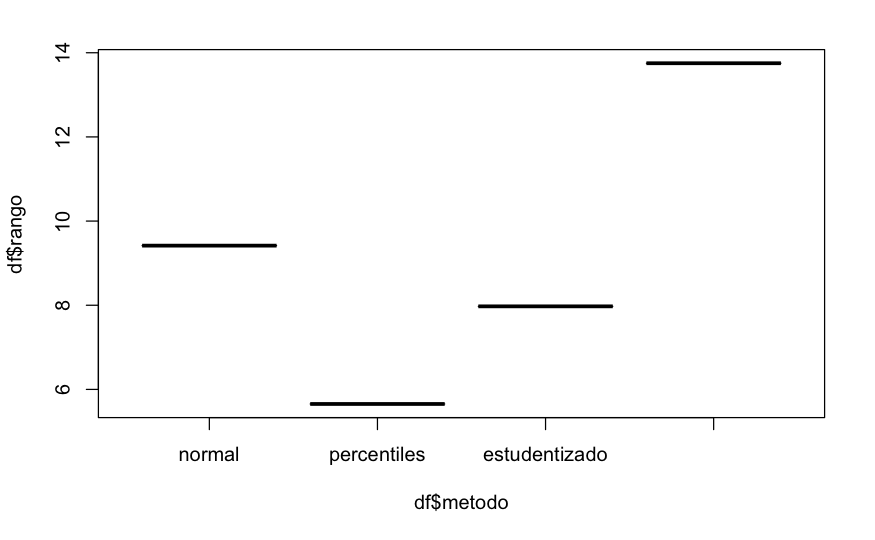

```r
boxplot(df$rango ~ df$metodo)
```